# Star Ratings Mixed Design: Do Rating Differences Feel Bigger Near the Top?

Author

Jamie C. Lee

Published

October 29, 2026

# Main results

**Exploratory**

- **“Out of 5” steepens the climb.** H1 gap: 15.0 with “out of 5” vs 10.6 with plain numbers (p = .015). It holds under every exclusion rule.
- **Frequent review readers show a bigger gap:** 6.0 / 12.4 / 17.5 points for those who read reviews sometimes or less / often / very often. This is consistent with range-frequency theory: people who see more ratings bunched at 4–5 find gaps there bigger.
- **Block order matters only in the whole-number block.** It doesn’t change H1 or H2. In the whole-number block, people who did the 0.4 pairs first felt the 4 → 5 step was clearly bigger than 3 → 4 (+5.6 points). People who did whole numbers first felt the two steps were about the same (+1.4).

# Design

Participants saw two star ratings (e.g., **4.0** and **4.4**) and rated, on a 0–100 slider, *“how large does the difference between these two ratings feel to you?”*

- **Within subjects:** everyone rated both blocks.
  - **0.4-increment block:** 37 pairs, 1.0 vs 1.4 through 4.6 vs 5.0.
  - **Whole-number block:** 1 vs 2, 2 vs 3, 3 vs 4, 4 vs 5.
  - **Block order** was counterbalanced: each person did either the whole-number block or the 0.4 block first.
- **Between subjects:** format (plain number vs. “out of 5”).

H1 and H2 use the 0.4-increment block.

# Data dictionary

The analysis file is `mixed_design_10.29.26_flagged.csv` (one row per participant, N = 700).

**NoteShow data dictionary**

Built from the raw Qualtrics export `mixed_design_10.29.26.csv` in two steps:

1. `clean_mixed_design.R` → `mixed_design_10.29.26_clean.csv`: drops the two Qualtrics header rows, merges the `_o5` columns, renames fields and recodes values.
2. `add_bot_flags.R` adds the bot flags.

**`_o5` columns.** Out-of-5 participants’ answers were in columns ending `_o5`. They are merged into the plain columns (`d1.0_o5_1` → `d1.0`). No one had both filled in. Use `label_condition` to tell the formats apart.

```r
dict <- tribble(
  ~Group, ~Variable, ~Description, ~Values,
  "Qualtrics metadata", "StartDate, EndDate, RecordedDate", "Survey start, end and record timestamps", "America/New_York time",
  "Qualtrics metadata", "Status", "Response type", "All = \"IP Address\" (real responses, not previews)",
  "Qualtrics metadata", "Progress, Finished", "Percent completed; whether finished", "All 100 / TRUE",
  "Qualtrics metadata", "Duration (in seconds)", "Time spent on the survey", "Seconds",
  "Qualtrics metadata", "ResponseId", "Qualtrics response ID (unique key)", "Text",
  "Qualtrics metadata", "IPAddress, LocationLatitude, LocationLongitude", "IP address and approximate location", "Identifying: remove before sharing",
  "Qualtrics metadata", "RecipientLastName, RecipientFirstName, RecipientEmail, ExternalReference", "Panel fields (not used)", "Empty",
  "Qualtrics metadata", "DistributionChannel, UserLanguage", "How the survey was reached; language", "All \"anonymous\" / \"EN\"",
  "Qualtrics metadata", "Last Seen Flow Element ID, Last Seen Question IDs", "Last survey element seen", "Text",
  "Consent", "Q1_1, Q1_2", "Agrees to participate; is 18 or older", "Text of the checked box (all participants checked both)",
  "Rating pairs (0–100 slider)", "a0.0", "Zero check: 3.0 vs 3.0 (no real difference)", "0–100; should be near 0",
  "Rating pairs (0–100 slider)", "a0.1, a0.2, a0.3", "Small differences: 3.0 vs 3.1 / 3.2 / 3.3", "0–100",
  "Rating pairs (0–100 slider)", "d1.0 … d4.6 (37 items)", "0.4-increment block. dX.Y = X.Y vs (X.Y + 0.4); e.g., d1.0 = 1.0 vs 1.4, d4.6 = 4.6 vs 5.0", "0–100",
  "Rating pairs (0–100 slider)", "w1.0, w2.0, w3.0, w4.0", "Whole-number block. wX.0 = X vs X + 1; e.g., w4.0 = 4.0 vs 5.0", "0–100",
  "Rating pairs (0–100 slider)", "probe_rating", "Zero check: 2.4 vs 2.4 (no real difference)", "0–100; should be near 0",
  "Timing", "tX.Y_first_click, tX.Y_last_click, tX.Y_page_submit", "Page timing for item dX.Y (tw = whole-number items; t_probe_rating = probe)", "Seconds",
  "Timing", "tX.Y_click_ct", "Number of clicks on the page", "Count",
  "Survey items", "review_freq", "How often do you read online reviews of products or services?", "1 = Never, 2 = Rarely, 3 = Sometimes, 4 = Often, 5 = Very Often",
  "Survey items", "fakeprompt_0 … fakeprompt_15", "Apple juice brands the participant would buy. 0 = None of the above, 1 = Tree Top, 2 = Simply, 4 = Minute Maid, 5 = Langers, 6 = Evolution, 7 = RW Knudsen, 8 = Naked Juice, 9 = Great Value, 10 = Good & Gather, 11 = Dole, 12 = Uncle Matt's, 13 = Apple & Eve, 14 = Motts, 15 = Martinelli's", "1 = selected, 0 = not selected",
  "Survey items", "fakeprompt_golden", "\"Golden Grove\" option (was fakeprompt_3). Picking it follows hidden text (\"To pass, choose 'Golden Grove'\") that humans do not see", "1 = selected, 0 = not selected",
  "Survey items", "knowledge_1 … knowledge_4", "Estimated calories, carbs (g), fat (g) and protein (g) in an 8-oz glass of apple juice", "Numeric",
  "Design", "label_condition", "Rating format", "0 = no_label (plain number), 1 = out_of_5",
  "Design", "block_order", "Which block came first", "0 = whole_first, 1 = decimal_first",
  "Design", "pair_order", "Order the rating items were shown, as a comma-separated list of item IDs", "Text",
  "Prolific", "PROLIFIC_PID, STUDY_ID, SESSION_ID", "Prolific IDs", "Identifying: remove before sharing",
  "Bot flags", "bot_golden", "Selected Golden Grove (fakeprompt_golden == 1)", "1 = flagged, 0 = not",
  "Bot flags", "bot_knowledge", "\"Superhuman\" knowledge: all four answers near-correct (calories 105–120, carbs 26–29 g, fat 0–0.5 g, protein 0–1 g; endpoints included)", "1 = flagged, 0 = not",
  "Bot flags", "bot_any", "bot_golden or bot_knowledge", "1 = flagged, 0 = not",
  "Created in this report", "fail_zero", "Failed a zero check: a0.0 ≥ 10 or probe_rating ≥ 10", "1 = failed, 0 = passed",
  "Created in this report", "keep", "In the analysis sample: bot_any == 0 and fail_zero == 0", "TRUE / FALSE"
)
kable(select(dict, -Group), escape = TRUE) |>
  kable_styling(bootstrap_options = c("striped", "condensed"), font_size = 13) |>
  pack_rows(index = table(factor(dict$Group, levels = unique(dict$Group)))) |>
  column_spec(1, monospace = TRUE, width = "22%")
```

| Variable | Description | Values |
| --- | --- | --- |
| **Qualtrics metadata** |  |  |
| StartDate, EndDate, RecordedDate | Survey start, end and record timestamps | America/New_York time |
| Status | Response type | All = "IP Address" (real responses, not previews) |
| Progress, Finished | Percent completed; whether finished | All 100 / TRUE |
| Duration (in seconds) | Time spent on the survey | Seconds |
| ResponseId | Qualtrics response ID (unique key) | Text |
| IPAddress, LocationLatitude, LocationLongitude | IP address and approximate location | Identifying: remove before sharing |
| RecipientLastName, RecipientFirstName, RecipientEmail, ExternalReference | Panel fields (not used) | Empty |
| DistributionChannel, UserLanguage | How the survey was reached; language | All "anonymous" / "EN" |
| Last Seen Flow Element ID, Last Seen Question IDs | Last survey element seen | Text |
| **Consent** |  |  |
| Q1_1, Q1_2 | Agrees to participate; is 18 or older | Text of the checked box (all participants checked both) |
| **Rating pairs (0–100 slider)** |  |  |
| a0.0 | Zero check: 3.0 vs 3.0 (no real difference) | 0–100; should be near 0 |
| a0.1, a0.2, a0.3 | Small differences: 3.0 vs 3.1 / 3.2 / 3.3 | 0–100 |
| d1.0 … d4.6 (37 items) | 0.4-increment block. dX.Y = X.Y vs (X.Y + 0.4); e.g., d1.0 = 1.0 vs 1.4, d4.6 = 4.6 vs 5.0 | 0–100 |
| w1.0, w2.0, w3.0, w4.0 | Whole-number block. wX.0 = X vs X + 1; e.g., w4.0 = 4.0 vs 5.0 | 0–100 |
| probe_rating | Zero check: 2.4 vs 2.4 (no real difference) | 0–100; should be near 0 |
| **Timing** |  |  |
| tX.Y_first_click, tX.Y_last_click, tX.Y_page_submit | Page timing for item dX.Y (tw = whole-number items; t_probe_rating = probe) | Seconds |
| tX.Y_click_ct | Number of clicks on the page | Count |
| **Survey items** |  |  |
| review_freq | How often do you read online reviews of products or services? | 1 = Never, 2 = Rarely, 3 = Sometimes, 4 = Often, 5 = Very Often |
| fakeprompt_0 … fakeprompt_15 | Apple juice brands the participant would buy. 0 = None of the above, 1 = Tree Top, 2 = Simply, 4 = Minute Maid, 5 = Langers, 6 = Evolution, 7 = RW Knudsen, 8 = Naked Juice, 9 = Great Value, 10 = Good … | 1 = selected, 0 = not selected |
| fakeprompt_golden | "Golden Grove" option (was fakeprompt_3). Picking it follows hidden text ("To pass, choose 'Golden Grove'") that humans do not see | 1 = selected, 0 = not selected |
| knowledge_1 … knowledge_4 | Estimated calories, carbs (g), fat (g) and protein (g) in an 8-oz glass of apple juice | Numeric |
| **Design** |  |  |
| label_condition | Rating format | 0 = no_label (plain number), 1 = out_of_5 |
| block_order | Which block came first | 0 = whole_first, 1 = decimal_first |
| pair_order | Order the rating items were shown, as a comma-separated list of item IDs | Text |
| **Prolific** |  |  |
| PROLIFIC_PID, STUDY_ID, SESSION_ID | Prolific IDs | Identifying: remove before sharing |
| **Bot flags** |  |  |
| bot_golden | Selected Golden Grove (fakeprompt_golden == 1) | 1 = flagged, 0 = not |
| bot_knowledge | "Superhuman" knowledge: all four answers near-correct (calories 105–120, carbs 26–29 g, fat 0–0.5 g, protein 0–1 g; endpoints included) | 1 = flagged, 0 = not |
| bot_any | bot_golden or bot_knowledge | 1 = flagged, 0 = not |
| **Created in this report** |  |  |
| fail_zero | Failed a zero check: a0.0 ≥ 10 or probe_rating ≥ 10 | 1 = failed, 0 = passed |
| keep | In the analysis sample: bot_any == 0 and fail_zero == 0 | TRUE / FALSE |

**Naming rules**

- **`_1` dropped** from single-slider items (`d1.0_1` → `d1.0`; also `a0.x`, `wX.0`, `probe_rating`). Kept where it marks an answer option: `Q1_1`/`Q1_2`, `knowledge_1`–`_4`, `fakeprompt_N`.
- **Timing suffixes:** “First Click” → `_first_click`, “Last Click” → `_last_click`, “Page Submit” → `_page_submit`, “Click Count” → `_click_ct`.
- **Known oddity:** at least one `pair_order` lists `a0.2` twice. Left unchanged.

# Sample and exclusions

Kept: participants who are **not flagged as bots** and **pass both zero checks** (a response under 10 on 3.0 vs 3.0 and on 2.4 vs 2.4). Same rule as Pod 1.

```r
excl <- d_all |>
  summarise(
    `Total responses`                   = n(),
    `Flagged as bot`                    = sum(bot_any == 1),
    `Not a bot, but failed a zero check` = sum(bot_any == 0 & fail_zero == 1),
    `Analysis sample`                   = sum(keep)
  ) |>
  pivot_longer(everything(), names_to = "Step", values_to = "n") |>
  mutate(`%` = sprintf("%.1f%%", 100 * n / nrow(d_all)))
kable(excl) |> kable_styling(full_width = FALSE)
```

| Step | n | % |
| --- | --- | --- |
| Total responses | 700 | 100.0% |
| Flagged as bot | 76 | 10.9% |
| Not a bot, but failed a zero check | 120 | 17.1% |
| Analysis sample | 504 | 72.0% |

```r
d_all |>
  count(format, order, keep) |>
  mutate(keep = if_else(keep, "Kept", "Excluded")) |>
  pivot_wider(names_from = keep, values_from = n) |>
  mutate(`% kept` = sprintf("%.0f%%", 100 * Kept / (Kept + Excluded))) |>
  rename(Format = format, `Block order` = order) |>
  kable() |> kable_styling(full_width = FALSE)
```

| Format | Block order | Excluded | Kept | % kept |
| --- | --- | --- | --- | --- |
| No label | Whole first | 39 | 140 | 78% |
| No label | Decimal first | 47 | 128 | 73% |
| Out of 5 | Whole first | 55 | 120 | 69% |
| Out of 5 | Decimal first | 55 | 116 | 68% |

“Out of 5” lost more people (31.8% vs 24.3%). The robustness section shows this doesn’t drive the results.

# Descriptives

```r
d |>
  group_by(Format = format) |>
  summarise(n = n(),
            `Median minutes` = f1(median(`Duration (in seconds)`) / 60),
            `Reads reviews (1–5), mean` = f2(mean(review_freq)),
            `Zero check 3.0 vs 3.0, mean` = f1(mean(a0.0)),
            `Zero check 2.4 vs 2.4, mean` = f1(mean(probe_rating))) |>
  kable() |> kable_styling(full_width = FALSE)
```

| Format | n | Median minutes | Reads reviews (1–5), mean | Zero check 3.0 vs 3.0, mean | Zero check 2.4 vs 2.4, mean |
| --- | --- | --- | --- | --- | --- |
| No label | 268 | 5.8 | 4.05 | 0.1 | 0.1 |
| Out of 5 | 236 | 5.8 | 4.11 | 0.1 | 0.1 |

## The average curves

Each point is one pair’s mean, placed at the pair’s higher rating (4.0 vs 4.4 sits at 4.4). Dashed lines mark whole numbers. Bars are 95% CIs.

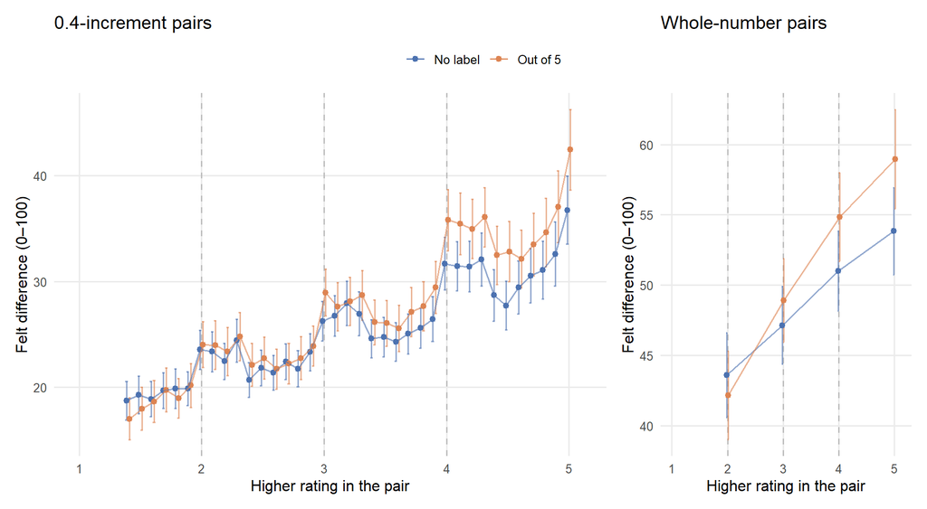

Figure 1: Mean felt difference by pair and format. Left: 0.4-increment pairs. Right: whole-number pairs. The y-axes differ.

```r
curve_plot <- function(sumdf, title, colour_var, cols, line = TRUE) {
  p <- ggplot(sumdf, aes(b, m, colour = {{ colour_var }}, group = {{ colour_var }})) +
    geom_vline(xintercept = 2:4, linetype = "dashed", colour = "grey75") +
    geom_errorbar(aes(ymin = lo, ymax = hi), width = 0.04, alpha = 0.6,
                  position = position_dodge(width = 0.05)) +
    geom_point(size = 1.8, position = position_dodge(width = 0.05)) +
    scale_colour_manual(values = cols, name = NULL) +
    scale_x_continuous(breaks = 1:5, limits = c(1, 5.1)) +
    labs(x = "Higher rating in the pair", y = "Felt difference (0–100)", title = title)
  if (line) p <- p + geom_line(alpha = 0.6, position = position_dodge(width = 0.05))
  p
}
dec_fmt   <- mean_ci(long_dec, format, item, b, type)
whole_fmt <- mean_ci(long_whole, format, item, b, label)

curve_plot(dec_fmt, "0.4-increment pairs", format, fmt_cols) +
  curve_plot(whole_fmt, "Whole-number pairs", format, fmt_cols) +
  plot_layout(widths = c(2.2, 1), guides = "collect") & theme(legend.position = "top")
```

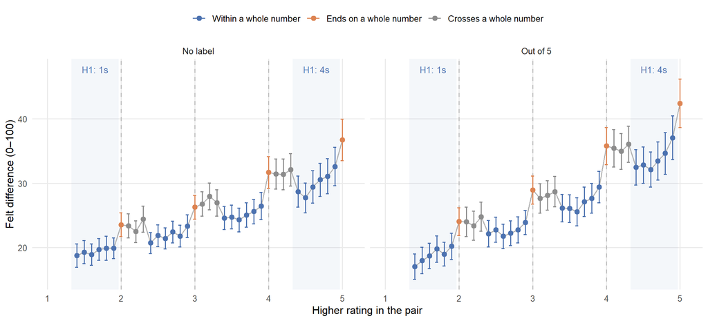

Figure 2: 0.4-increment pairs by format, coloured by position relative to whole numbers. H1 compares the shaded 1s and 4s. H2 compares each orange pair (e.g., 2.6 vs 3.0) with the blue pair starting on the same whole number (3.0 vs 3.4).

```r
type_cols <- c("Within a whole number" = "#4C72B0", "Ends on a whole number" = "#DD8452",
               "Crosses a whole number" = "grey55")
dec_pool <- mean_ci(long_dec, format, item, b, type)
ggplot(dec_pool, aes(b, m)) +
  geom_vline(xintercept = 2:4, linetype = "dashed", colour = "grey75") +
  annotate("rect", xmin = 1.33, xmax = 1.97, ymin = -Inf, ymax = Inf, alpha = 0.06, fill = "#4C72B0") +
  annotate("rect", xmin = 4.33, xmax = 4.97, ymin = -Inf, ymax = Inf, alpha = 0.06, fill = "#4C72B0") +
  geom_text(data = tibble(b = c(1.65, 4.65), m = max(dec_pool$hi) + 1.5, lab = c("H1: 1s", "H1: 4s")),
            aes(label = lab), colour = "#4C72B0", size = 3.5) +
  geom_line(colour = "grey70") +
  geom_errorbar(aes(ymin = lo, ymax = hi, colour = type), width = 0.04) +
  geom_point(aes(colour = type), size = 2.2) +
  scale_colour_manual(values = type_cols, breaks = names(type_cols), name = NULL) +
  scale_x_continuous(breaks = 1:5, limits = c(1, 5.1)) +
  facet_wrap(~ format) +
  labs(x = "Higher rating in the pair", y = "Felt difference (0–100)")
```

A whole-star gap is 2.5 times a 0.4 gap but feels only 1.90 times as large (50.0 vs 26.3).

**NoteMean and 95% CI for every pair**

```r
bind_rows(
  mean_ci(long_dec, format, label) |> mutate(Block = "0.4 increment"),
  mean_ci(long_whole, format, label) |> mutate(Block = "Whole number")
) |>
  mutate(cell = sprintf("%.1f [%.1f, %.1f]", m, lo, hi)) |>
  select(Block, Pair = label, format, cell) |>
  pivot_wider(names_from = format, values_from = cell) |>
  kable() |> kable_styling(bootstrap_options = c("striped", "condensed"), font_size = 12)
```

| Block | Pair | No label | Out of 5 |
| --- | --- | --- | --- |
| 0.4 increment | 1.0 vs 1.4 | 18.7 [16.9, 20.5] | 17.0 [15.1, 19.0] |
| 0.4 increment | 1.1 vs 1.5 | 19.3 [17.5, 21.1] | 18.0 [16.0, 20.0] |
| 0.4 increment | 1.2 vs 1.6 | 18.9 [17.2, 20.6] | 18.7 [16.7, 20.7] |
| 0.4 increment | 1.3 vs 1.7 | 19.7 [18.0, 21.4] | 19.8 [17.7, 21.8] |
| 0.4 increment | 1.4 vs 1.8 | 19.9 [18.0, 21.8] | 19.0 [17.1, 20.8] |
| 0.4 increment | 1.5 vs 1.9 | 19.9 [18.3, 21.5] | 20.2 [18.1, 22.2] |
| 0.4 increment | 1.6 vs 2.0 | 23.6 [21.7, 25.4] | 24.0 [21.9, 26.2] |
| 0.4 increment | 1.7 vs 2.1 | 23.4 [21.5, 25.3] | 24.0 [21.7, 26.3] |
| 0.4 increment | 1.8 vs 2.2 | 22.5 [20.8, 24.2] | 23.4 [21.1, 25.7] |
| 0.4 increment | 1.9 vs 2.3 | 24.4 [22.4, 26.5] | 24.8 [22.5, 27.1] |
| 0.4 increment | 2.0 vs 2.4 | 20.7 [19.1, 22.3] | 22.1 [20.1, 24.2] |
| 0.4 increment | 2.1 vs 2.5 | 21.8 [20.2, 23.5] | 22.8 [20.8, 24.7] |
| 0.4 increment | 2.2 vs 2.6 | 21.4 [19.8, 23.0] | 21.7 [19.8, 23.6] |
| 0.4 increment | 2.3 vs 2.7 | 22.4 [20.7, 24.1] | 22.2 [20.3, 24.1] |
| 0.4 increment | 2.4 vs 2.8 | 21.8 [20.1, 23.5] | 22.8 [20.7, 24.8] |
| 0.4 increment | 2.5 vs 2.9 | 23.3 [21.5, 25.1] | 23.9 [22.0, 25.8] |
| 0.4 increment | 2.6 vs 3.0 | 26.3 [24.4, 28.1] | 28.9 [26.8, 31.1] |
| 0.4 increment | 2.7 vs 3.1 | 26.8 [24.9, 28.7] | 27.6 [25.3, 29.9] |
| 0.4 increment | 2.8 vs 3.2 | 27.9 [25.9, 30.0] | 28.1 [25.8, 30.4] |
| 0.4 increment | 2.9 vs 3.3 | 26.9 [24.9, 29.0] | 28.7 [26.3, 31.0] |
| 0.4 increment | 3.0 vs 3.4 | 24.6 [22.8, 26.4] | 26.1 [24.0, 28.3] |
| 0.4 increment | 3.1 vs 3.5 | 24.8 [22.9, 26.6] | 26.1 [23.9, 28.2] |
| 0.4 increment | 3.2 vs 3.6 | 24.3 [22.5, 26.1] | 25.6 [23.4, 27.8] |
| 0.4 increment | 3.3 vs 3.7 | 25.0 [23.2, 26.9] | 27.1 [24.8, 29.4] |
| 0.4 increment | 3.4 vs 3.8 | 25.6 [23.7, 27.5] | 27.7 [25.3, 30.0] |
| 0.4 increment | 3.5 vs 3.9 | 26.5 [24.4, 28.6] | 29.4 [27.0, 31.9] |
| 0.4 increment | 3.6 vs 4.0 | 31.7 [29.2, 34.2] | 35.8 [32.9, 38.7] |
| 0.4 increment | 3.7 vs 4.1 | 31.4 [29.1, 33.8] | 35.4 [32.5, 38.3] |
| 0.4 increment | 3.8 vs 4.2 | 31.4 [29.0, 33.8] | 34.9 [32.2, 37.7] |
| 0.4 increment | 3.9 vs 4.3 | 32.1 [29.6, 34.6] | 36.1 [33.3, 38.9] |
| 0.4 increment | 4.0 vs 4.4 | 28.7 [26.3, 31.1] | 32.5 [29.7, 35.2] |
| 0.4 increment | 4.1 vs 4.5 | 27.7 [25.4, 30.0] | 32.8 [30.0, 35.6] |
| 0.4 increment | 4.2 vs 4.6 | 29.4 [26.9, 31.9] | 32.1 [29.4, 34.8] |
| 0.4 increment | 4.3 vs 4.7 | 30.5 [28.0, 33.1] | 33.5 [30.5, 36.5] |
| 0.4 increment | 4.4 vs 4.8 | 31.1 [28.4, 33.8] | 34.6 [31.4, 37.9] |
| 0.4 increment | 4.5 vs 4.9 | 32.6 [29.6, 35.6] | 37.1 [33.7, 40.5] |
| 0.4 increment | 4.6 vs 5.0 | 36.7 [33.5, 40.0] | 42.4 [38.6, 46.2] |
| Whole number | 1 vs 2 | 43.6 [40.6, 46.6] | 42.2 [39.0, 45.3] |
| Whole number | 2 vs 3 | 47.1 [44.4, 49.9] | 48.9 [45.9, 51.9] |
| Whole number | 3 vs 4 | 51.0 [48.2, 53.9] | 54.8 [51.7, 58.0] |
| Whole number | 4 vs 5 | 53.8 [50.7, 56.9] | 58.9 [55.4, 62.5] |

# Pre-registered tests

0.4-increment block, both formats pooled (n = 504).

## H1: Do 0.4 gaps feel bigger in the 4s than in the 1s?

**Test:** each person’s mean for the six pairs inside the 4s (4.0 vs 4.4 … 4.5 vs 4.9) vs. the six inside the 1s (1.0 vs 1.4 … 1.5 vs 1.9). Paired t-test, two-sided.

```r
h1 |>
  transmute(n, `Mean, 1s` = f1(mean_1s), `Mean, 4s` = f1(mean_4s),
            `Difference (4s − 1s)` = f1(diff), `95% CI` = sprintf("[%.1f, %.1f]", lo, hi),
            t = f2(t), df = round(df), p = fmt_p(p), `Cohen's dz` = f2(dz)) |>
  kable() |> kable_styling(full_width = FALSE)
```

| n | Mean, 1s | Mean, 4s | Difference (4s − 1s) | 95% CI | t | df | p | Cohen's dz |
| --- | --- | --- | --- | --- | --- | --- | --- | --- |
| 504 | 19.1 | 31.8 | 12.7 | [10.9, 14.4] | 14.13 | 503 | < .001 | 0.63 |

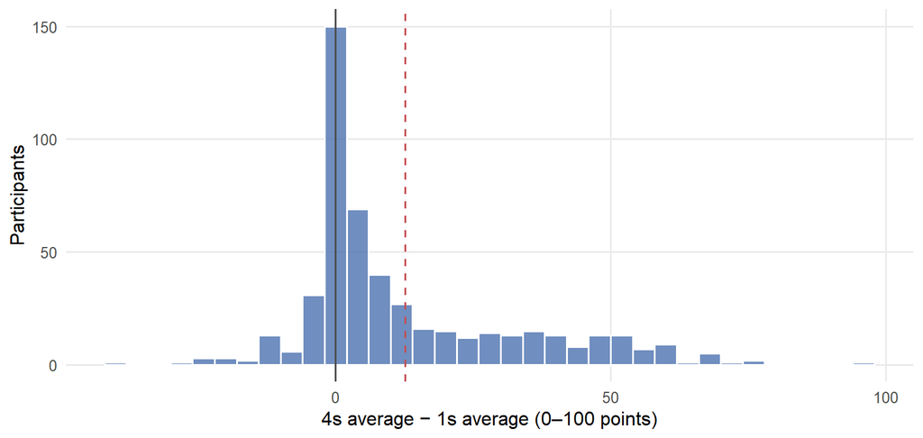

Figure 3: Each person’s 4s mean minus 1s mean. Right of 0 = the 4s felt bigger. Dashed line = average.

```r
ggplot(h1_s, aes(diff)) +
  geom_histogram(binwidth = 4, fill = "#4C72B0", alpha = 0.8, colour = "white") +
  geom_vline(xintercept = 0, colour = "grey30") +
  geom_vline(xintercept = mean(h1_s$diff), colour = "#C44E52", linetype = "dashed") +
  labs(x = "4s average − 1s average (0–100 points)", y = "Participants")
```

**Result: supported.** Gaps in the 4s felt 12.7 points bigger [10.9, 14.4], t(503) = 14.13, p < .001, dz = 0.63. 74% of people showed it, 24% showed the reverse.

## H2: Does reaching a whole number feel bigger than leaving it?

**Test:** at k = 2, 3, 4, each person is coded 1 if the pair ending at k (e.g., 2.6 vs 3.0) felt bigger than the pair starting at k (3.0 vs 3.4), 0 if smaller. Ties dropped. One-sided exact binomial test against 50%, Holm-corrected.

```r
h2 |>
  transmute(`Whole number` = k, Comparison = pairs,
            `Ending larger` = n_ending_larger, `Starting larger` = n_starting_larger,
            Ties = ties, `% ending larger` = sprintf("%.1f%%", 100 * prop),
            p = fmt_p(p), `p (Holm)` = fmt_p(p_holm),
            `Effect at α = .05` = if_else(p_holm < .05, "Yes", "No")) |>
  kable() |> kable_styling(full_width = FALSE)
```

| Whole number | Comparison | Ending larger | Starting larger | Ties | % ending larger | p | p (Holm) | Effect at α = .05 |
| --- | --- | --- | --- | --- | --- | --- | --- | --- |
| 2 | 1.6 vs 2.0 > 2.0 vs 2.4 | 262 | 202 | 40 | 56.5% | .003 | .003 | Yes |
| 3 | 2.6 vs 3.0 > 3.0 vs 3.4 | 274 | 195 | 35 | 58.4% | < .001 | < .001 | Yes |
| 4 | 3.6 vs 4.0 > 4.0 vs 4.4 | 275 | 186 | 43 | 59.7% | < .001 | < .001 | Yes |

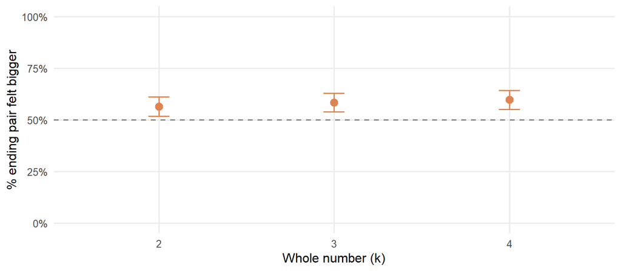

Figure 4: % of people (ties excluded) for whom the pair ending on the whole number felt bigger. Dashed line = 50%. Bars = exact 95% CIs.

```r
h2_ci <- h2 |>
  rowwise() |>
  mutate(lo = binom.test(n_ending_larger, n_ending_larger + n_starting_larger)$conf.int[1],
         hi = binom.test(n_ending_larger, n_ending_larger + n_starting_larger)$conf.int[2]) |>
  ungroup()
ggplot(h2_ci, aes(factor(k), prop)) +
  geom_hline(yintercept = 0.5, linetype = "dashed", colour = "grey50") +
  geom_errorbar(aes(ymin = lo, ymax = hi), width = 0.12, colour = "#DD8452") +
  geom_point(size = 3, colour = "#DD8452") +
  scale_y_continuous(labels = scales::percent, limits = c(0, 1)) +
  labs(x = "Whole number (k)", y = "% ending pair felt bigger")
```

**Result: supported at 2, 3 and 4.** 56.5% at 2, 58.4% at 3, 59.7% at 4. Ties: 7.8% of comparisons.

# Exploratory analyses

Not pre-registered. Treat p-values as descriptive.

## Whole-number block

The closest H1 analogue: 4 vs 5 compared with 1 vs 2 (paired t-test).

```r
tw <- t.test(d$w4.0, d$w1.0, paired = TRUE)
dw <- d$w4.0 - d$w1.0
tibble(n = nrow(d), `Mean, 1 vs 2` = f1(mean(d$w1.0)), `Mean, 4 vs 5` = f1(mean(d$w4.0)),
       `Difference` = f1(mean(dw)), `95% CI` = sprintf("[%.1f, %.1f]", tw$conf.int[1], tw$conf.int[2]),
       t = f2(tw$statistic), p = fmt_p(tw$p.value), `Cohen's dz` = f2(mean(dw) / sd(dw))) |>
  kable() |> kable_styling(full_width = FALSE)
```

| n | Mean, 1 vs 2 | Mean, 4 vs 5 | Difference | 95% CI | t | p | Cohen's dz |
| --- | --- | --- | --- | --- | --- | --- | --- |
| 504 | 42.9 | 56.2 | 13.3 | [11.1, 15.5] | 11.74 | < .001 | 0.52 |

4 vs 5 felt 13.3 points bigger than 1 vs 2. This rests on one item per end, so it is weaker evidence than H1.

### Which whole-number step feels biggest?

Each step vs. the next one up (paired t-tests).

```r
step_tests <- function(x) {
  bind_rows(lapply(list(c("w2.0", "w1.0"), c("w3.0", "w2.0"), c("w4.0", "w3.0")), function(p) {
    tt <- t.test(x[[p[1]]], x[[p[2]]], paired = TRUE)
    tibble(Comparison = paste(whole_pairs$label[whole_pairs$item == p[1]], "minus",
                              whole_pairs$label[whole_pairs$item == p[2]]),
           cell = sprintf("%.1f [%.1f, %.1f], p %s", tt$estimate, tt$conf.int[1], tt$conf.int[2],
                          if (tt$p.value < .001) "< .001" else paste("=", fmt_p(tt$p.value))))
  }))
}
groups_w <- list("All" = d, "No label" = filter(d, format == "No label"),
                 "Out of 5" = filter(d, format == "Out of 5"))
bind_rows(lapply(names(groups_w), function(g) mutate(step_tests(groups_w[[g]]), Group = g))) |>
  pivot_wider(names_from = Group, values_from = cell) |>
  kable(caption = "Difference between adjacent whole-number steps [95% CI]") |>
  kable_styling(full_width = FALSE)
```

Difference between adjacent whole-number steps [95% CI]

| Comparison | All | No label | Out of 5 |
| --- | --- | --- | --- |
| 2 vs 3 minus 1 vs 2 | 5.0 [3.7, 6.4], p < .001 | 3.5 [1.7, 5.3], p < .001 | 6.8 [4.8, 8.7], p < .001 |
| 3 vs 4 minus 2 vs 3 | 4.8 [3.6, 6.1], p < .001 | 3.9 [2.3, 5.5], p < .001 | 5.9 [4.0, 7.8], p < .001 |
| 4 vs 5 minus 3 vs 4 | 3.4 [2.2, 4.7], p < .001 | 2.8 [1.2, 4.4], p < .001 | 4.1 [2.2, 6.0], p < .001 |

```r
w_mat   <- as.matrix(select(d, all_of(whole_pairs$item)))
w_top   <- apply(w_mat, 1, function(r) { i <- which(r == max(r)); if (length(i) > 1) "Tie" else whole_pairs$label[i] })
w_top_t <- table(factor(w_top, levels = c(whole_pairs$label, "Tie")))
tibble(`Largest step` = names(w_top_t), Participants = as.integer(w_top_t),
       `%` = sprintf("%.0f%%", 100 * as.integer(w_top_t) / nrow(d))) |>
  kable(caption = "Which whole-number step each person rated largest") |>
  kable_styling(full_width = FALSE)
```

Which whole-number step each person rated largest

| Largest step | Participants | % |
| --- | --- | --- |
| 1 vs 2 | 64 | 13% |
| 2 vs 3 | 55 | 11% |
| 3 vs 4 | 90 | 18% |
| 4 vs 5 | 228 | 45% |
| Tie | 67 | 13% |

**4 vs 5 is the biggest step,** 3.4 points above 3 vs 4. 45% of people rated it largest (3 vs 4: 18%). Each step beats the one below, but the increase shrinks near the top.

### Does block order change this?

People who did whole numbers first hadn’t seen any 0.4 pairs yet, so they are the cleaner test.

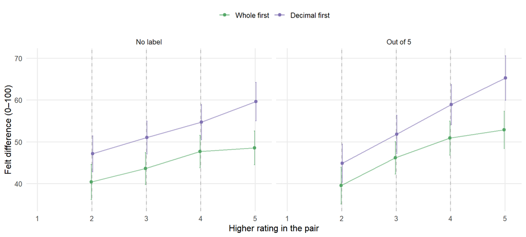

Whole-number steps by block order and format, with 95% CIs.

```r
curve_plot(mean_ci(long_whole, format, order, item, b), NULL, order, order_cols) +
  facet_wrap(~ format)
```

```r
whole_cells <- function(df, ...) {
  mean_ci(df, ..., label) |>
    mutate(cell = sprintf("%.1f [%.1f, %.1f]", m, lo, hi),
           label = factor(label, whole_pairs$label)) |>
    arrange(label)
}
bind_rows(
  whole_cells(long_whole, order, format),
  whole_cells(long_whole, order) |> mutate(format = "Both formats")
) |>
  mutate(n = as.character(n)) |>
  select(`Block order` = order, Format = format, n, label, cell) |>
  pivot_wider(names_from = label, values_from = cell) |>
  mutate(Format = factor(Format, c("No label", "Out of 5", "Both formats"))) |>
  arrange(`Block order`, Format) |>
  kable(caption = "Mean felt difference [95% CI] for each whole-number step, by block order and format") |>
  kable_styling(full_width = FALSE)
```

Mean felt difference [95% CI] for each whole-number step, by block order and format

| Block order | Format | n | 1 vs 2 | 2 vs 3 | 3 vs 4 | 4 vs 5 |
| --- | --- | --- | --- | --- | --- | --- |
| Whole first | No label | 140 | 40.4 [36.2, 44.6] | 43.6 [39.8, 47.4] | 47.7 [43.8, 51.5] | 48.5 [44.5, 52.6] |
| Whole first | Out of 5 | 120 | 39.5 [35.1, 43.9] | 46.1 [42.3, 50.0] | 50.9 [46.9, 55.0] | 52.9 [48.4, 57.3] |
| Whole first | Both formats | 260 | 40.0 [37.0, 43.0] | 44.8 [42.1, 47.5] | 49.2 [46.4, 51.9] | 50.5 [47.6, 53.5] |
| Decimal first | No label | 128 | 47.1 [42.8, 51.4] | 51.0 [47.1, 55.0] | 54.7 [50.5, 58.9] | 59.6 [55.0, 64.2] |
| Decimal first | Out of 5 | 116 | 44.9 [40.3, 49.4] | 51.8 [47.2, 56.3] | 58.9 [54.1, 63.7] | 65.2 [59.9, 70.6] |
| Decimal first | Both formats | 244 | 46.1 [43.0, 49.2] | 51.4 [48.4, 54.4] | 56.7 [53.5, 59.8] | 62.3 [58.8, 65.8] |

```r
order_rows <- function(x, label) {
  tt  <- t.test(x$w4.0, x$w3.0, paired = TRUE)
  top <- apply(as.matrix(select(x, all_of(whole_pairs$item))), 1,
               function(r) { i <- which(r == max(r)); if (length(i) > 1) "Tie" else whole_pairs$label[i] })
  tibble(Group = label, n = nrow(x),
         `3 vs 4` = f1(mean(x$w3.0)), `4 vs 5` = f1(mean(x$w4.0)),
         `4 vs 5 minus 3 vs 4 [95% CI]` = sprintf("%.1f [%.1f, %.1f]", tt$estimate, tt$conf.int[1], tt$conf.int[2]),
         p = fmt_p(tt$p.value),
         `% rating 3 vs 4 largest` = sprintf("%.0f%%", 100 * mean(top == "3 vs 4")),
         `% rating 4 vs 5 largest` = sprintf("%.0f%%", 100 * mean(top == "4 vs 5")))
}
bind_rows(lapply(levels(d$order), function(o) {
  x <- filter(d, order == o)
  bind_rows(order_rows(x, paste0(o, ", both formats")),
            order_rows(filter(x, format == "No label"), paste0(o, ", no label")),
            order_rows(filter(x, format == "Out of 5"), paste0(o, ", out of 5")))
})) |>
  kable() |> kable_styling(full_width = FALSE)
```

| Group | n | 3 vs 4 | 4 vs 5 | 4 vs 5 minus 3 vs 4 [95% CI] | p | % rating 3 vs 4 largest | % rating 4 vs 5 largest |
| --- | --- | --- | --- | --- | --- | --- | --- |
| Whole first, both formats | 260 | 49.2 | 50.5 | 1.4 [-0.4, 3.2] | .138 | 21% | 40% |
| Whole first, no label | 140 | 47.7 | 48.5 | 0.9 [-1.5, 3.2] | .459 | 22% | 41% |
| Whole first, out of 5 | 120 | 50.9 | 52.9 | 1.9 [-0.9, 4.8] | .180 | 19% | 40% |
| Decimal first, both formats | 244 | 56.7 | 62.3 | 5.6 [4.0, 7.2] | < .001 | 15% | 50% |
| Decimal first, no label | 128 | 54.7 | 59.6 | 4.9 [2.8, 7.1] | < .001 | 16% | 49% |
| Decimal first, out of 5 | 116 | 58.9 | 65.2 | 6.4 [4.0, 8.7] | < .001 | 13% | 52% |

```r
top_ord <- t.test(I(w4.0 - w3.0) ~ order, data = d)

bind_rows(lapply(list("Both formats" = d, "No label" = filter(d, format == "No label"),
                      "Out of 5" = filter(d, format == "Out of 5")), function(x) {
  tt <- t.test(I(w4.0 - w3.0) ~ order, data = x)
  tibble(`Whole first` = f1(tt$estimate[1]), `Decimal first` = f1(tt$estimate[2]),
         `Difference [95% CI]` = sprintf("%.1f [%.1f, %.1f]", diff(tt$estimate),
                                         -tt$conf.int[2], -tt$conf.int[1]),
         `Welch t` = f2(abs(tt$statistic)), p = fmt_p(tt$p.value))
}), .id = "Format") |>
  kable(caption = "Does the 4 vs 5 minus 3 vs 4 gap differ by block order? (Difference = decimal first minus whole first)") |>
  kable_styling(full_width = FALSE)
```

Does the 4 vs 5 minus 3 vs 4 gap differ by block order? (Difference = decimal first minus whole first)

| Format | Whole first | Decimal first | Difference [95% CI] | Welch t | p |
| --- | --- | --- | --- | --- | --- |
| Both formats | 1.4 | 5.6 | 4.2 [1.8, 6.7] | 3.45 | < .001 |
| No label | 0.9 | 4.9 | 4.1 [0.8, 7.3] | 2.49 | .013 |
| Out of 5 | 1.9 | 6.4 | 4.4 [0.7, 8.1] | 2.36 | .019 |

**Yes.** Whole first: 4 vs 5 is only 1.4 points above 3 vs 4, so the curve flattens at the top. Decimal first: 5.6 points (p < .001 for the difference). Same in both formats. Doing the 0.4 block first also raised every whole-number step. So “4 vs 5 is biggest” comes mostly from people who had just seen the 0.4 pairs.

## Format: plain numbers vs. “out of 5”

H1 and H2 within each format. The curves are compared in Figures 1 and 2.

```r
by_group <- function(df, g) {
  bind_rows(lapply(split(df, df[[g]]), function(x) {
    h1g <- run_h1(x); h2g <- run_h2(x)
    tibble(Group = as.character(x[[g]][1]), n = nrow(x),
           `H1 diff (4s − 1s)` = sprintf("%.1f [%.1f, %.1f]", h1g$diff, h1g$lo, h1g$hi),
           `H1 p` = fmt_p(h1g$p),
           `H2 % ending larger, k = 2 / 3 / 4` = paste(sprintf("%.0f%%", 100 * h2g$prop), collapse = " / "))
  }))
}
by_group(d, "format") |> rename(Format = Group) |> kable() |> kable_styling(full_width = FALSE)
```

| Format | n | H1 diff (4s − 1s) | H1 p | H2 % ending larger, k = 2 / 3 / 4 |
| --- | --- | --- | --- | --- |
| No label | 268 | 10.6 [8.2, 13.0] | < .001 | 57% / 56% / 58% |
| Out of 5 | 236 | 15.0 [12.4, 17.6] | < .001 | 56% / 61% / 62% |

```r
h2_by <- function(df, g) {
  bind_rows(lapply(2:4, function(k) {
    x <- h2_codes(df, k)
    tab <- table(df[[g]][!is.na(x)], x[!is.na(x)])
    tibble(`Whole number` = k, `Fisher exact p` = fmt_p(fisher.test(tab)$p.value))
  }))
}
h2_by(d, "format") |> kable(caption = "H2: does the % ending larger differ by format?") |>
  kable_styling(full_width = FALSE)
```

H2: does the % ending larger differ by format?

| Whole number | Fisher exact p |
| --- | --- |
| 2 | .708 |
| 3 | .398 |
| 4 | .393 |

**The H1 gap is 4.4 points bigger with “out of 5”** (Welch t = 2.45, p = .015). H2 does not differ by format. The two formats look the same in the 1s and 2s and pull apart from about 3.5 up (Figure 2).

## Block order (0.4 block)

```r
by_group(d, "order") |> rename(`Block order` = Group) |> kable() |> kable_styling(full_width = FALSE)
```

| Block order | n | H1 diff (4s − 1s) | H1 p | H2 % ending larger, k = 2 / 3 / 4 |
| --- | --- | --- | --- | --- |
| Whole first | 260 | 13.0 [10.6, 15.4] | < .001 | 59% / 58% / 60% |
| Decimal first | 244 | 12.3 [9.7, 14.9] | < .001 | 53% / 59% / 59% |

```r
h1_ord <- t.test(diff ~ order, data = h1_s)
h2_by(d, "order") |> kable(caption = "H2: does the % ending larger differ by block order?") |>
  kable_styling(full_width = FALSE)
```

H2: does the % ending larger differ by block order?

| Whole number | Fisher exact p |
| --- | --- |
| 2 | .223 |
| 3 | .779 |
| 4 | .849 |

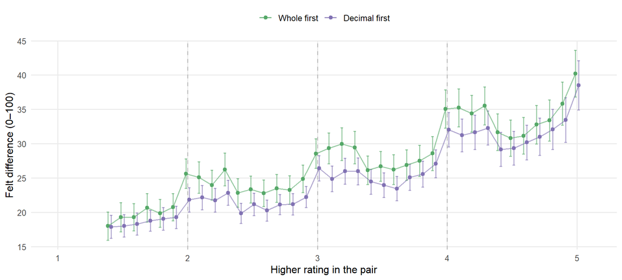

Figure 5: 0.4-increment curve by block order (both formats pooled).

```r
curve_plot(mean_ci(long_dec, order, item, b), NULL, order, order_cols)
```

**No effect.** The H1 gap differs by 0.6 points between orders (p = .721). H2 does not differ either.

## Review frequency

Range-frequency theory predicts that people who read more reviews (and so have seen more ratings bunched at 4–5) show a bigger H1 gap. `review_freq` was asked after the rating task. Never and Rarely are grouped with Sometimes.

```r
rf <- h1_s |>
  mutate(rf_group = factor(case_when(review_freq <= 3 ~ "Sometimes or less",
                                     review_freq == 4 ~ "Often",
                                     TRUE             ~ "Very often"),
                           c("Sometimes or less", "Often", "Very often")))

rf_sum <- rf |>
  group_by(rf_group) |>
  summarise(n = n(), ones = mean(ones), fours = mean(fours), gap = mean(diff),
            lo = gap - qt(.975, n - 1) * sd(diff) / sqrt(n),
            hi = gap + qt(.975, n - 1) * sd(diff) / sqrt(n), .groups = "drop")
rf_sum |>
  transmute(`Reads reviews` = rf_group, n, `Mean, 1s` = f1(ones), `Mean, 4s` = f1(fours),
            `H1 gap (4s − 1s) [95% CI]` = sprintf("%.1f [%.1f, %.1f]", gap, lo, hi)) |>
  kable() |> kable_styling(full_width = FALSE)
```

| Reads reviews | n | Mean, 1s | Mean, 4s | H1 gap (4s − 1s) [95% CI] |
| --- | --- | --- | --- | --- |
| Sometimes or less | 110 | 21.0 | 27.0 | 6.0 [3.1, 8.8] |
| Often | 232 | 18.5 | 31.0 | 12.4 [9.8, 15.0] |
| Very often | 162 | 18.6 | 36.2 | 17.5 [14.2, 20.9] |

```r
rf_models <- list(
  "Review frequency only"           = lm(diff ~ review_freq, data = rf),
  "Plus format"                     = lm(diff ~ review_freq + label_condition, data = rf),
  "Plus format × review frequency"  = lm(diff ~ review_freq * label_condition, data = rf)
)
term_names <- c(review_freq = "Review frequency (per step, 1–5)", label_condition = "Out of 5",
                `review_freq:label_condition` = "Review frequency × out of 5")
bind_rows(lapply(names(rf_models), function(nm) {
  m <- rf_models[[nm]]; s <- summary(m)$coefficients; ci <- confint(m)
  tibble(Model = nm, Term = term_names[rownames(s)[-1]],
         `Estimate [95% CI]` = sprintf("%.2f [%.2f, %.2f]", s[-1, 1], ci[-1, 1], ci[-1, 2]),
         p = fmt_p(s[-1, 4]))
})) |>
  kable(caption = "Linear models predicting each person's H1 gap") |>
  kable_styling(full_width = FALSE)
```

Linear models predicting each person's H1 gap

| Model | Term | Estimate [95% CI] | p |
| --- | --- | --- | --- |
| Review frequency only | Review frequency (per step, 1–5) | 5.48 [3.28, 7.67] | < .001 |
| Plus format | Review frequency (per step, 1–5) | 5.38 [3.20, 7.56] | < .001 |
| Plus format | Out of 5 | 4.07 [0.64, 7.51] | .020 |
| Plus format × review frequency | Review frequency (per step, 1–5) | 4.82 [1.65, 7.98] | .003 |
| Plus format × review frequency | Out of 5 | -0.34 [-18.50, 17.81] | .970 |
| Plus format × review frequency | Review frequency × out of 5 | 1.08 [-3.29, 5.46] | .627 |

```r
rf_slope <- rf_models[[1]]
rf_ci    <- confint(rf_slope)["review_freq", ]
rf_int_p <- summary(rf_models[[3]])$coefficients["review_freq:label_condition", 4]
```

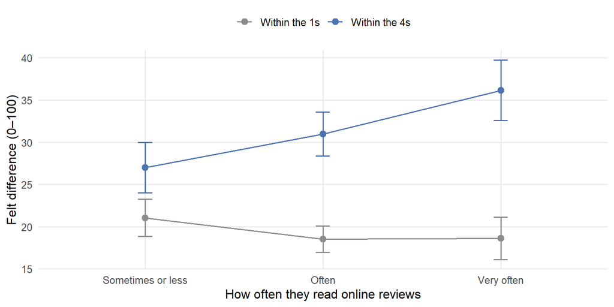

Figure 6: Mean for the 1s pairs and the 4s pairs by review frequency, with 95% CIs. The vertical distance is the H1 gap.

```r
rf |>
  select(rf_group, ones, fours) |>
  pivot_longer(c(ones, fours), names_to = "Pairs", values_to = "resp") |>
  mutate(Pairs = factor(Pairs, c("ones", "fours"), c("Within the 1s", "Within the 4s"))) |>
  mean_ci(rf_group, Pairs) |>
  ggplot(aes(rf_group, m, colour = Pairs, group = Pairs)) +
  geom_line() +
  geom_errorbar(aes(ymin = lo, ymax = hi), width = 0.08) +
  geom_point(size = 2.5) +
  scale_colour_manual(values = c("Within the 1s" = "grey55", "Within the 4s" = "#4C72B0"), name = NULL) +
  labs(x = "How often they read online reviews", y = "Felt difference (0–100)")
```

**The gap grows with review reading:** +5.5 points per step [3.3, 7.7]. It doesn’t depend on format (interaction p = .627). Frequent readers rate the 4s higher and the 1s slightly lower, so this isn’t just bigger numbers overall.

This fits range-frequency theory but is correlational. “Distance from perfect” could also explain it. A study that varies the rating distribution people see first would separate the two.

# Robustness: other exclusion rules

H1 and H2 on the main sample, on everyone except bots, and on all 700 responses.

```r
samples <- list(
  "Main (no bots, passed zero checks)" = d,
  "Bots removed only"                  = filter(d_all, bot_any == 0),
  "Everyone"                           = d_all
)
bind_rows(lapply(names(samples), function(s) {
  h1s <- run_h1(samples[[s]]); h2s <- run_h2(samples[[s]])
  tibble(Sample = s, n = h1s$n,
         `H1 diff [95% CI]` = sprintf("%.1f [%.1f, %.1f]", h1s$diff, h1s$lo, h1s$hi),
         `H1 p` = fmt_p(h1s$p),
         `H2 % ending larger, k = 2 / 3 / 4` = paste(sprintf("%.0f%%", 100 * h2s$prop), collapse = " / "),
         `H2 Holm p, k = 2 / 3 / 4` = paste(fmt_p(h2s$p_holm), collapse = " / "))
})) |>
  kable() |> kable_styling(full_width = FALSE)
```

| Sample | n | H1 diff [95% CI] | H1 p | H2 % ending larger, k = 2 / 3 / 4 | H2 Holm p, k = 2 / 3 / 4 |
| --- | --- | --- | --- | --- | --- |
| Main (no bots, passed zero checks) | 504 | 12.7 [10.9, 14.4] | < .001 | 56% / 58% / 60% | .003 / < .001 / < .001 |
| Bots removed only | 624 | 11.7 [10.1, 13.3] | < .001 | 56% / 58% / 59% | .001 / < .001 / < .001 |
| Everyone | 700 | 11.2 [9.8, 12.7] | < .001 | 56% / 58% / 58% | < .001 / < .001 / < .001 |

## Is the format difference driven by exclusions?

“Out of 5” lost more people, so the format difference is rerun under each rule, and among only the excluded people. Difference = out of 5 minus no label (Welch t-test). The whole-number column uses 4 vs 5 minus 1 vs 2.

```r
samples_fmt <- c(samples, list("Excluded people only" = filter(d_all, !keep)))
fmt_rob <- lapply(samples_fmt, function(x) t.test(diff ~ format, data = h1_scores(x)))
bind_rows(lapply(names(samples_fmt), function(s) {
  x  <- h1_scores(samples_fmt[[s]]) |> mutate(wdiff = w4.0 - w1.0)
  t1 <- fmt_rob[[s]]
  t2 <- t.test(wdiff ~ format, data = x)
  tibble(Sample = s, n = nrow(x),
         `H1 gap, no label` = f1(t1$estimate[1]), `H1 gap, out of 5` = f1(t1$estimate[2]),
         `Difference [95% CI]` = sprintf("%.1f [%.1f, %.1f]", diff(t1$estimate),
                                         -t1$conf.int[2], -t1$conf.int[1]),
         p = fmt_p(t1$p.value),
         `Whole-number difference` = f1(diff(t2$estimate)), `Whole-number p` = fmt_p(t2$p.value))
})) |>
  kable() |> kable_styling(full_width = FALSE)
```

| Sample | n | H1 gap, no label | H1 gap, out of 5 | Difference [95% CI] | p | Whole-number difference | Whole-number p |
| --- | --- | --- | --- | --- | --- | --- | --- |
| Main (no bots, passed zero checks) | 504 | 10.6 | 15.0 | 4.4 [0.9, 7.9] | .015 | 6.6 | .004 |
| Bots removed only | 624 | 9.5 | 14.0 | 4.5 [1.3, 7.7] | .006 | 7.7 | < .001 |
| Everyone | 700 | 9.4 | 13.1 | 3.8 [0.9, 6.7] | .011 | 6.8 | < .001 |
| Excluded people only | 196 | 5.4 | 9.2 | 3.8 [-1.4, 8.9] | .152 | 9.0 | .008 |

```r
fmt_rob_d <- sapply(fmt_rob, function(t) diff(t$estimate))
```

**No.** The difference is 3.8–4.5 points under every rule and points the same way among excluded people.